# R Tutorial, BEE 2026

### Adding aesthetics and layers

Scatterplots are useful for displaying the relationship between two numerical variables, but it’s always a good idea to be skeptical of any apparent relationship between two variables and ask if there may be other variables that explain or change the nature of this apparent relationship. For example, does the relationship between flipper length and body mass differ by species? Let’s incorporate species into our plot and see if this reveals any additional insights into the apparent relationship between these variables. We will do this by representing species with different colored points.

To achieve this, will we need to modify the aesthetic or the geom? If you guessed “in the aesthetic mapping, inside of `aes()`”, you’re already getting the hang of creating data visualizations with ggplot2! And if not, don’t worry. Throughout the book you will make many more ggplots and have many more opportunities to check your intuition as you make them.

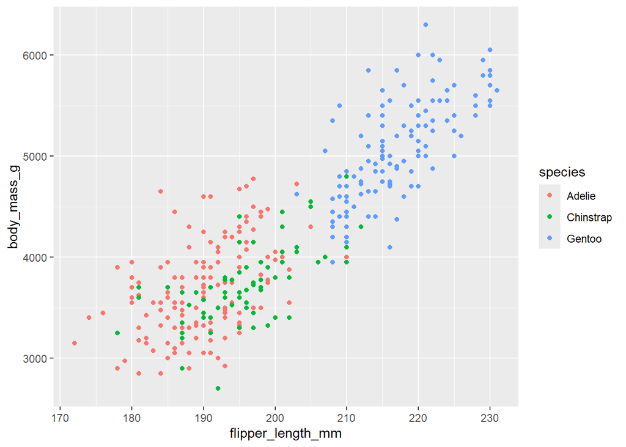

```r
ggplot(
  data = penguins,
  mapping = aes(x = flipper_length_mm, y = body_mass_g, color = species)
) +
  geom_point()
```

When a categorical variable is mapped to an aesthetic, ggplot2 will automatically assign a unique value of the aesthetic (here a unique color) to each unique level of the variable (each of the three species), a process known as **scaling**. ggplot2 will also add a legend that explains which values correspond to which levels.

Now let’s add one more layer: a smooth curve displaying the relationship between body mass and flipper length. Before you proceed, refer back to the code above, and think about how we can add this to our existing plot.

Since this is a new geometric object representing our data, we will add a new geom as a layer on top of our point geom: `geom_smooth()`. And we will specify that we want to draw the line of best fit based on a `l`inear `m`odel with `method = "lm"`.

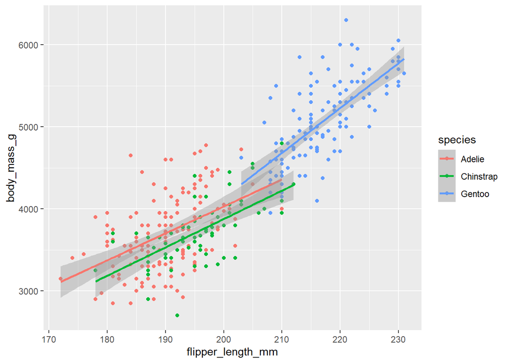

```r
ggplot(
  data = penguins,
  mapping = aes(x = flipper_length_mm, y = body_mass_g, color = species)
) +
  geom_point() +
  geom_smooth(method = "lm")
```

We have successfully added lines, but this plot doesn’t look like the plot from ultimate goal, which only has one line for the entire dataset as opposed to separate lines for each of the penguin species.

When aesthetic mappings are defined in `ggplot()`, at the *global* level, they’re passed down to each of the subsequent geom layers of the plot. However, each geom function in ggplot2 can also take a `mapping` argument, which allows for aesthetic mappings at the *local* level that are added to those inherited from the global level. Since we want points to be colored based on species but don’t want the lines to be separated out for them, we should specify `color = species` for `geom_point()` only.

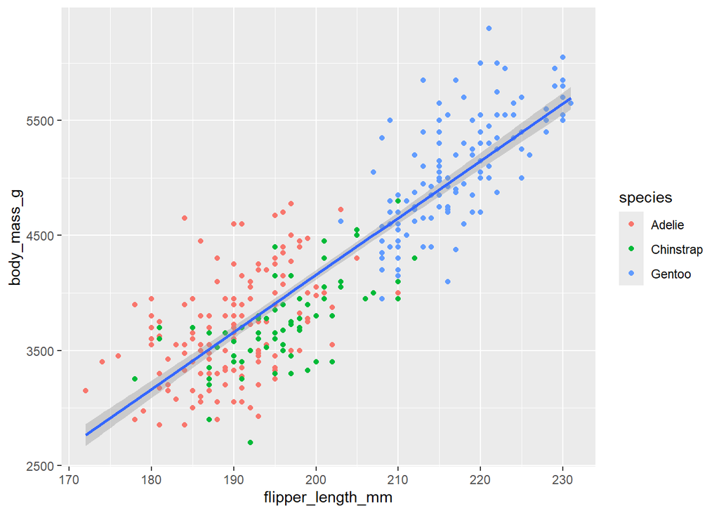

```r
ggplot(
  data = penguins,
  mapping = aes(x = flipper_length_mm, y = body_mass_g)
) +
  geom_point(mapping = aes(color = species)) +
  geom_smooth(method = "lm")
```

Voila! We have something that looks very much like our ultimate goal, though it’s not yet perfect. We still need to use different shapes for each species of penguins and improve labels.

It’s generally not a good idea to represent information using only colors on a plot, as people perceive colors differently due to color blindness or other color vision differences. Therefore, in addition to color, we can also map `species` to the `shape` aesthetic.

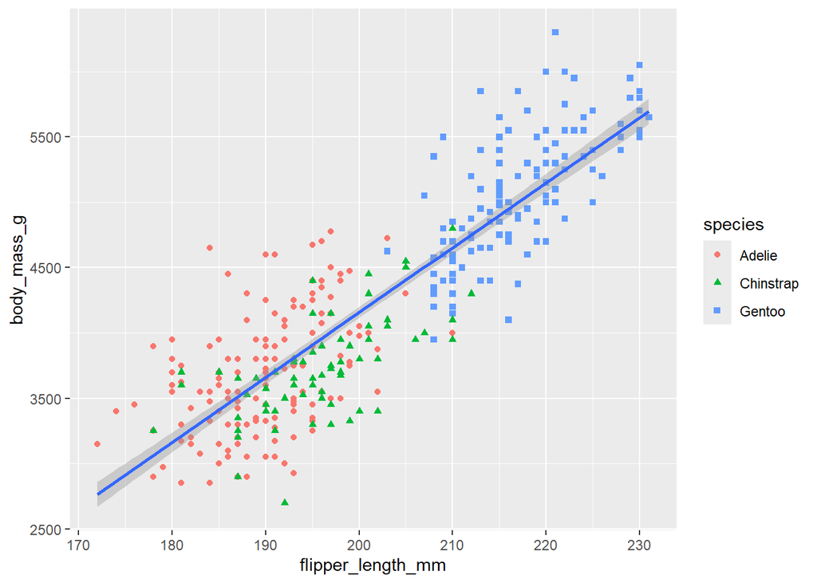

```r
ggplot(
  data = penguins,
  mapping = aes(x = flipper_length_mm, y = body_mass_g)
) +
  geom_point(mapping = aes(color = species, shape = species)) +
  geom_smooth(method = "lm")
```

Note that the legend is automatically updated to reflect the different shapes of the points as well.

And finally, we can improve the labels of our plot using the `labs()` function in a new layer. Some of the arguments to `labs()` might be self explanatory: `title` adds a title and `subtitle` adds a subtitle to the plot. Other arguments match the aesthetic mappings, `x` is the x-axis label, `y` is the y-axis label, and `color` and `shape` define the label for the legend. In addition, we can improve the color palette to be colorblind safe with the `scale_color_colorblind()` function from the ggthemes package.

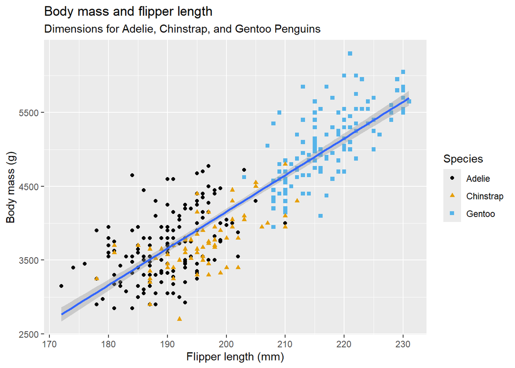

```r
ggplot(
  data = penguins,
  mapping = aes(x = flipper_length_mm, y = body_mass_g)
) +
  geom_point(aes(color = species, shape = species)) +
  geom_smooth(method = "lm") +
  labs(
    title = "Body mass and flipper length",
    subtitle = "Dimensions for Adelie, Chinstrap, and Gentoo Penguins",
    x = "Flipper length (mm)", y = "Body mass (g)",
    color = "Species", shape = "Species"
  ) +
  scale_color_colorblind()
```

We finally have a plot that perfectly matches our “ultimate goal”!

## Scripts

So far, you have used the console to run code. That’s a great place to start, but you’ll find it gets cramped pretty quickly as you create more complex ggplot2 graphics. To give yourself more room to work, use the script editor. Open it up by clicking the File menu, selecting New File, then R script, or using the keyboard shortcut Cmd/Ctrl + Shift + N. Now you’ll see four panes, as in the below figure. The script editor is a great place to experiment with your code. When you want to change something, you don’t have to re-type the whole thing, you can just edit the script and re-run it. And once you have written code that works and does what you want, you can save it as a script file to easily return to later.

[figure not shown]

Opening the script editor adds a new pane at the top-left of the IDE.

### Running code

The script editor is an excellent place for building complex ggplot2 plots or long sequences of data manipulation The key to using the script editor effectively is to memorize one of the most important keyboard shortcuts: Cmd/Ctrl + Enter. This executes the current R expression in the console. For example, take the code below.

```r
library(tidyverse)
library(palmerpenguins)

penguins_plot <- ggplot(data = penguins, mapping = aes(x = bill_length_mm, y = bill_depth_mm)) +
  geom_point()

penguins_col <- ggplot(data = penguins, mapping = aes(x = sex, y = bill_depth_mm)) +
  geom_col()
```

If your cursor is at `penguins_plot`, pressing Cmd/Ctrl + Enter will run the complete command that generates `penguins_plot`. It will also move the cursor to the following statement (beginning with `penguins_col`). That makes it easy to step through your complete script by repeatedly pressing Cmd/Ctrl + Enter.

Instead of running your code expression-by-expression, you can also execute the complete script in one step with Cmd/Ctrl + Shift + S. Doing this regularly is a great way to ensure that you’ve captured all the important parts of your code in the script.

We recommend you always start your script with the packages you need. That way, if you share your code with others, they can easily see which packages they need to install. Note, however, that you should never include `install.packages()` in a script you share. It’s inconsiderate to hand off a script that will change something on their computer if they’re not being careful!

When working through future chapters, we highly recommend starting in the script editor and practicing your keyboard shortcuts. Over time, sending code to the console in this way will become so natural that you won’t even think about it.

### RStudio diagnostics

Hover over the cross to see what the problem is:

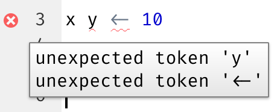

RStudio will also let you know about potential problems:

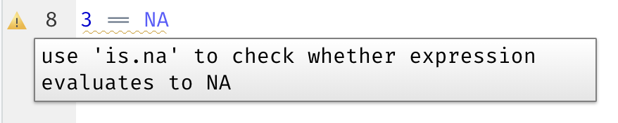

### Saving and naming

RStudio automatically saves the contents of the script editor when you quit, and automatically reloads it when you re-open. Nevertheless, it’s a good idea to avoid Untitled1, Untitled2, Untitled3, and so on and instead save your scripts and give them informative names.

It might be tempting to name your files `code.R` or `myscript.R`, but you should think a bit harder before choosing a name for your file. Three important principles for file naming are as follows:

1. File names should be **machine** readable: avoid spaces, symbols, and special characters. Don’t rely on case sensitivity to distinguish files.
2. File names should be **human** readable: use file names to describe what’s in the file.
3. File names should play well with default ordering: start file names with numbers so that alphabetical sorting puts them in the order they get used.

For example, suppose you have the following files in a project folder.

```
alternative model.R
code for exploratory analysis.r
finalreport.qmd
FinalReport.qmd
fig 1.png
Figure_02.png
model_first_try.R
run-first.r
temp.txt
```

There are a variety of problems here: it’s hard to find which file to run first, file names contain spaces, there are two files with the same name but different capitalization (`finalreport` vs. `FinalReport`[^3]), and some names don’t describe their contents (`run-first` and `temp`).

Here’s a better way of naming and organizing the same set of files:

```
01-load-data.R
02-exploratory-analysis.R
03-model-approach-1.R
04-model-approach-2.R
fig-01.png
fig-02.png
report-2022-03-20.qmd
report-2022-04-02.qmd
report-draft-notes.txt
```

Numbering the key scripts makes it obvious in which order to run them and a consistent naming scheme makes it easier to see what varies. Additionally, the figures are labelled similarly, the reports are distinguished by dates included in the file names, and `temp` is renamed to `report-draft-notes` to better describe its contents. If you have a lot of files in a directory, taking organization one step further and placing different types of files (scripts, figures, etc.) in different directories is recommended.

### Where does your analysis live?

R has a powerful notion of the **working directory**. This is where R looks for files that you ask it to load, and where it will put any files that you ask it to save. RStudio shows your current working directory at the top of the console:

[figure not shown]

And you can print this out in R code by running `getwd()`:

```r
getwd()
```

```
#> [1] "/Users/hadley/Documents/r4ds"
```

In this R session, the current working directory (think of it as “home”) is in hadley’s Documents folder, in a subfolder called r4ds. This code will return a different result when you run it, because your computer has a different directory structure than Hadley’s!

As a beginning R user, it’s OK to let your working directory be your home directory, documents directory, or any other weird directory on your computer. But you’re more than a handful of chapters into this book, and you’re no longer a beginner. Very soon now you should evolve to organizing your projects into directories and, when working on a project, set R’s working directory to the associated directory.

You can set the working directory from within R.

```r
setwd("/path/to/my/CoolProject")
```

### Data Visualization: Exercises 1

1. Using the `penguins` data from the `palmerpenguins` package, make a scatterplot of `bill_depth_mm` vs. `bill_length_mm`. That is, make a scatterplot with `bill_depth_mm` on the y-axis and `bill_length_mm` on the x-axis. Describe the relationship between these two variables. What do those 2 variables represent? Hint: Read the help for `?penguins` to find out.
2. Why does the following give an error and how would you fix it?

   ```r
   ggplot(data = penguins) +
     geom_point()
   ```

3. Add the following caption to the plot you made in the previous exercise: “Data come from the palmerpenguins package.” Hint: Take a look at the documentation for `labs()`.
4. Recreate the following visualization. What aesthetic should `bill_depth_mm` be mapped to? And should it be mapped at the global level or at the geom level?

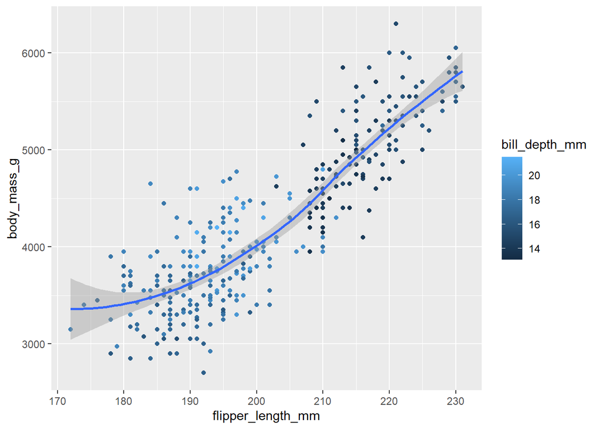

5. Will these two graphs look different? Why/why not?

   ```r
   ggplot(
     data = penguins,
     mapping = aes(x = flipper_length_mm, y = body_mass_g)
   ) +
     geom_point() +
     geom_smooth()

   ggplot() +
     geom_point(
       data = penguins,
       mapping = aes(x = flipper_length_mm, y = body_mass_g)
     ) +
     geom_smooth(
       data = penguins,
       mapping = aes(x = flipper_length_mm, y = body_mass_g)
     )
   ```

## Visualizing distributions

How you visualize the distribution of a variable depends on the type of variable: categorical or numerical.

### A categorical variable

A variable is **categorical** if it can only take one of a small set of values. To examine the distribution of a categorical variable, you can use a bar chart. The height of the bars displays how many observations occurred with each `x` value.

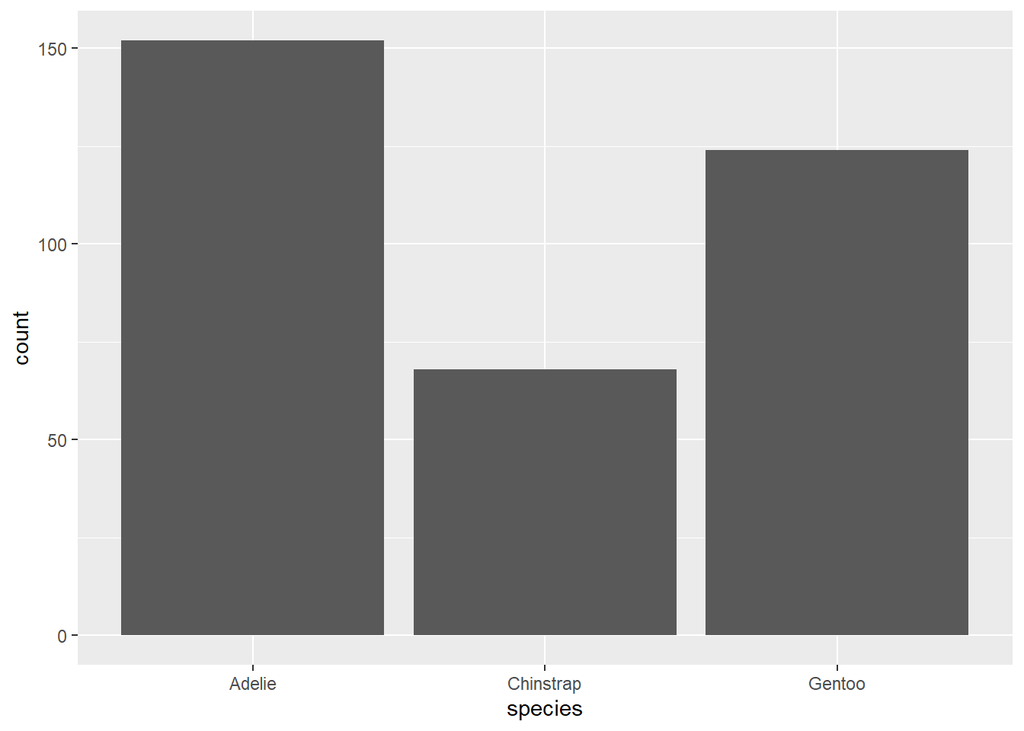

```r
ggplot(penguins, aes(x = species)) +
  geom_bar()
```

In bar plots of categorical variables with non-ordered levels, like the penguin `species` above, it’s often preferable to reorder the bars based on their frequencies. Doing so requires transforming the variable to a factor (how R handles categorical data) and then reordering the levels of that factor.

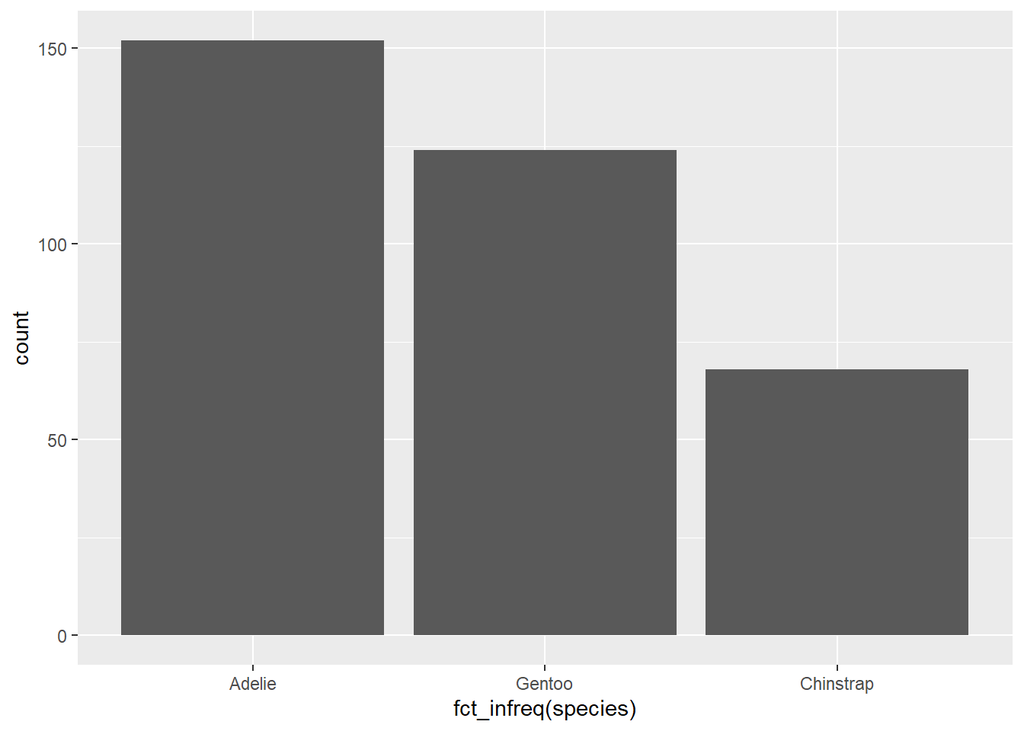

```r
ggplot(penguins, aes(x = fct_infreq(species))) +
  geom_bar()
```

### A numerical variable

A variable is **numerical** (or quantitative) if it can take on a wide range of numerical values, and it is sensible to add, subtract, or take averages with those values. Numerical variables can be continuous or discrete.

One commonly used visualization for distributions of continuous variables is a histogram.

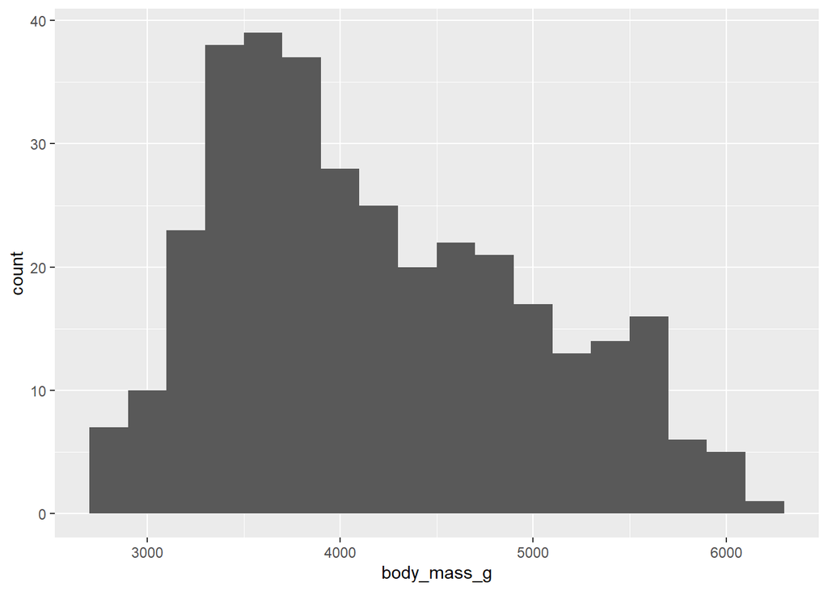

```r
ggplot(penguins, aes(x = body_mass_g)) +
  geom_histogram(binwidth = 200)
```

A histogram divides the x-axis into equally spaced bins and then uses the height of a bar to display the number of observations that fall in each bin. In the graph above, the tallest bar shows that 39 observations have a `body_mass_g` value between 3,500 and 3,700 grams, which are the left and right edges of the bar.

You can set the width of the intervals in a histogram with the binwidth argument, which is measured in the units of the `x` variable. You should always explore a variety of binwidths when working with histograms, as different binwidths can reveal different patterns. In the plots below a binwidth of 20 is too narrow, resulting in too many bars, making it difficult to determine the shape of the distribution. Similarly, a binwidth of 2,000 is too high, resulting in all data being binned into only three bars, and also making it difficult to determine the shape of the distribution. A binwidth of 200 provides a sensible balance.

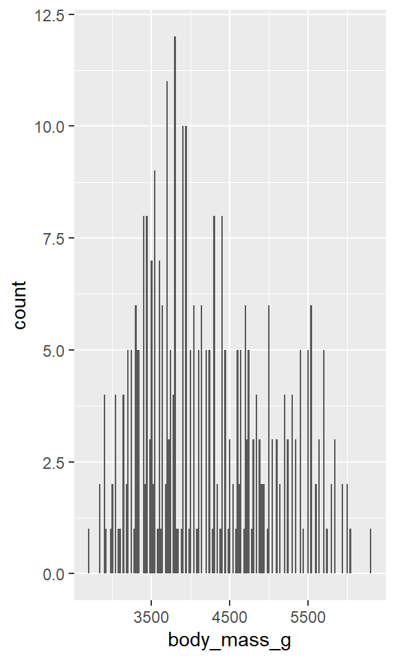

```r
ggplot(penguins, aes(x = body_mass_g)) +
  geom_histogram(binwidth = 20)
```

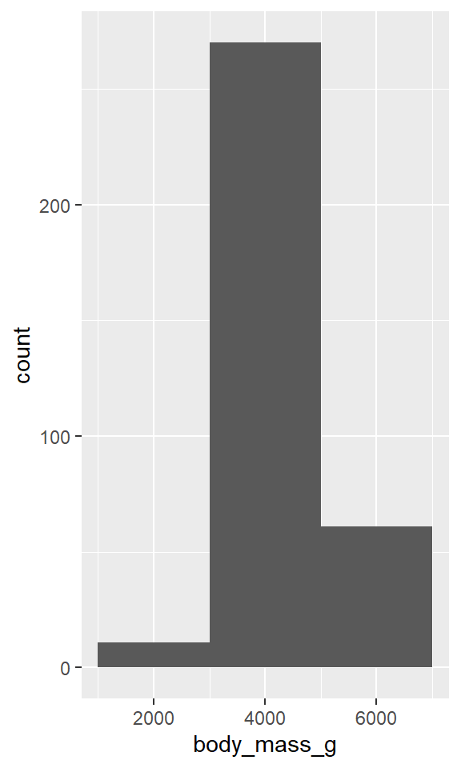

```r
ggplot(penguins, aes(x = body_mass_g)) +
  geom_histogram(binwidth = 2000)
```

An alternative visualization for distributions of numerical variables is a density plot. A density plot is a smoothed-out version of a histogram and a practical alternative, particularly for continuous data that comes from an underlying smooth distribution. We won’t go into how `geom_density()` estimates the density (you can read more about that in the function documentation), but let’s explain how the density curve is drawn with an analogy. Imagine a histogram made out of wooden blocks. Then, imagine that you drop a cooked spaghetti string over it. The shape the spaghetti will take draped over blocks can be thought of as the shape of the density curve. It shows fewer details than a histogram but can make it easier to quickly glean the shape of the distribution, particularly with respect to modes and skewness.

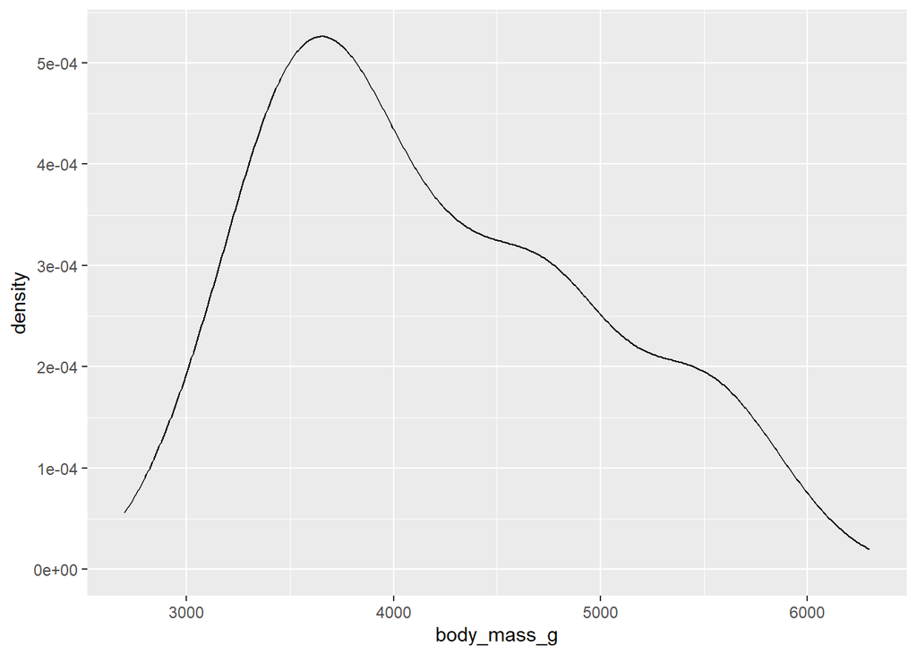

```r
ggplot(penguins, aes(x = body_mass_g)) +
  geom_density()
```

### Data Visualization: Exercises 2

1. Make a bar plot of `species` of `penguins`, where you assign `species` to the `y` aesthetic. How is this plot different?
2. How are the following two plots different? Which aesthetic, `color` or `fill`, is more useful for changing the color of bars?

   ```r
   ggplot(penguins, aes(x = species)) +
     geom_bar(color = "red")

   ggplot(penguins, aes(x = species)) +
     geom_bar(fill = "red")
   ```

3. Make a histogram of the `carat` variable in the `diamonds` dataset that is available when you load the tidyverse package. Experiment with different binwidths. What binwidth reveals the most interesting patterns?

## Visualizing relationships

To visualize a relationship we need to have at least two variables mapped to aesthetics of a plot. In the following sections you will learn about commonly used plots for visualizing relationships between two or more variables and the geoms used for creating them.

### A numerical and a categorical variable

- A box that indicates the range of the middle half of the data, a distance known as the interquartile range (IQR), stretching from the 25th percentile of the distribution to the 75th percentile. In the middle of the box is a line that displays the median, i.e. 50th percentile, of the distribution. These three lines give you a sense of the spread of the distribution and whether or not the distribution is symmetric about the median or skewed to one side.
- Visual points that display observations that fall more than 1.5 times the IQR from either edge of the box. These outlying points are unusual so are plotted individually.
- A line (or whisker) that extends from each end of the box and goes to the farthest non-outlier point in the distribution.

Let’s take a look at the distribution of body mass by species using `geom_boxplot()`:

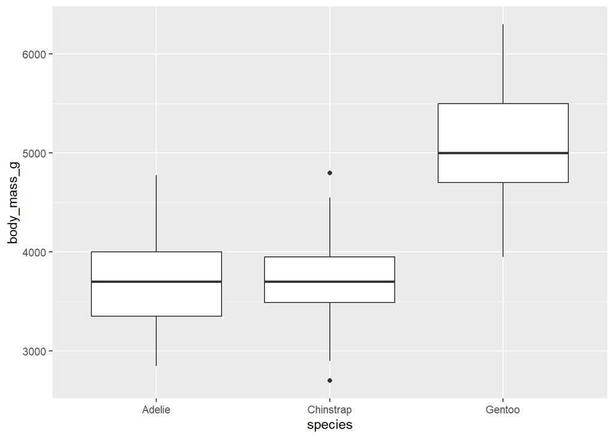

```r
ggplot(penguins, aes(x = species, y = body_mass_g)) +
  geom_boxplot()
```

Alternatively, we can make density plots with `geom_density()`.

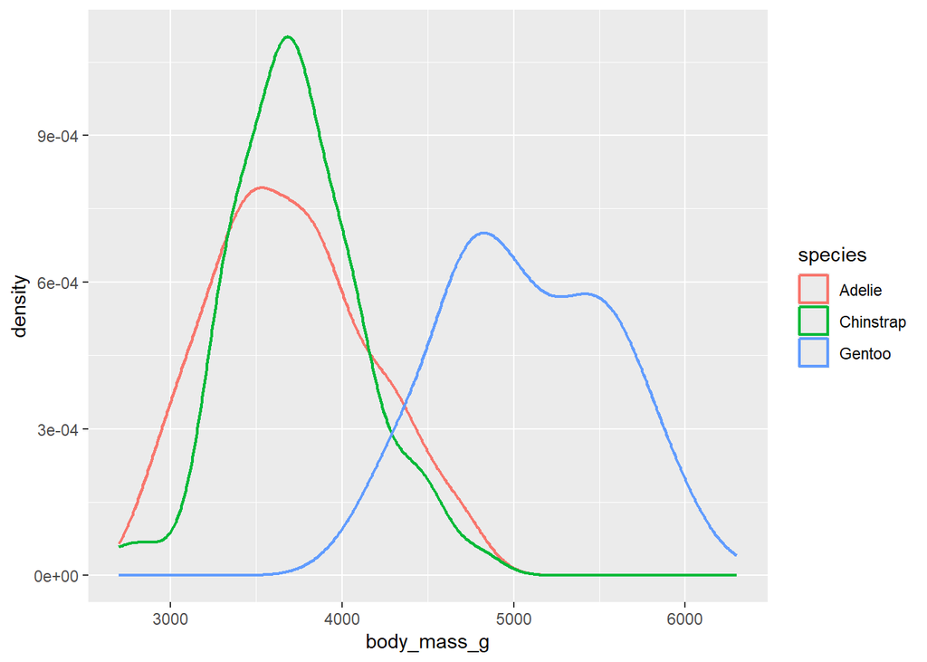

```r
ggplot(penguins, aes(x = body_mass_g, color = species)) +
  geom_density(linewidth = 0.75)
```

We’ve also customized the thickness of the lines using the `linewidth` argument in order to make them stand out a bit more against the background.

Additionally, we can map `species` to both `color` and `fill` aesthetics and use the `alpha` aesthetic to add transparency to the filled density curves. This aesthetic takes values between 0 (completely transparent) and 1 (completely opaque). In the following plot it’s *set* to 0.5.

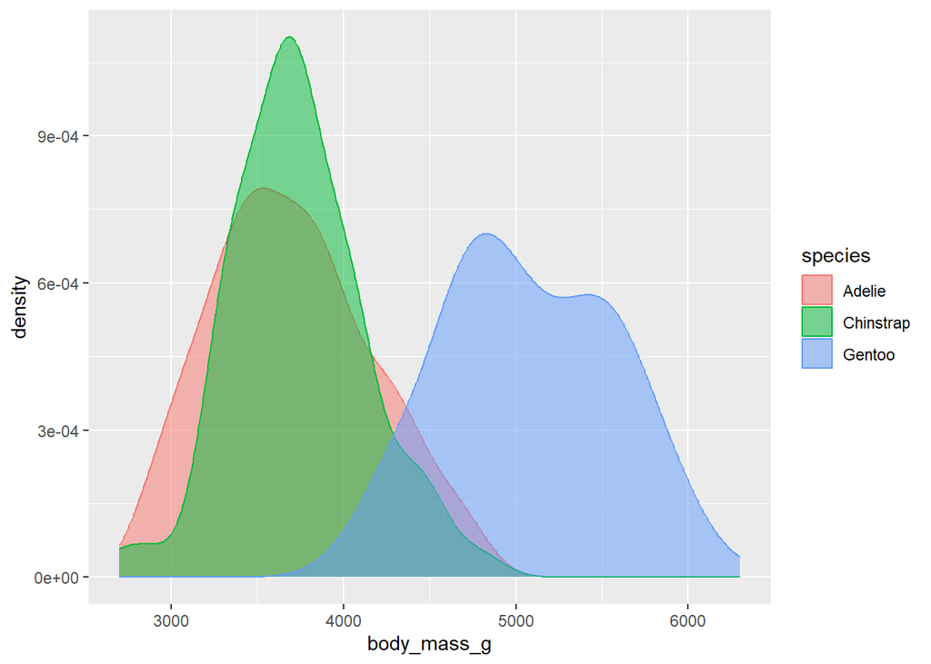

```r
ggplot(penguins, aes(x = body_mass_g, color = species, fill = species)) +
  geom_density(alpha = 0.5)
```

Note the terminology we have used here:

- We *map* variables to aesthetics if we want the visual attribute represented by that aesthetic to vary based on the values of that variable.
- Otherwise, we *set* the value of an aesthetic.

### Two categorical variables

We can use stacked bar plots to visualize the relationship between two categorical variables. For example, the following two stacked bar plots both display the relationship between `island` and `species`, or specifically, visualizing the distribution of `species` within each island.

The first plot shows the frequencies of each species of penguins on each island. The plot of frequencies shows that there are equal numbers of Adelies on each island. But we don’t have a good sense of the percentage balance within each island.

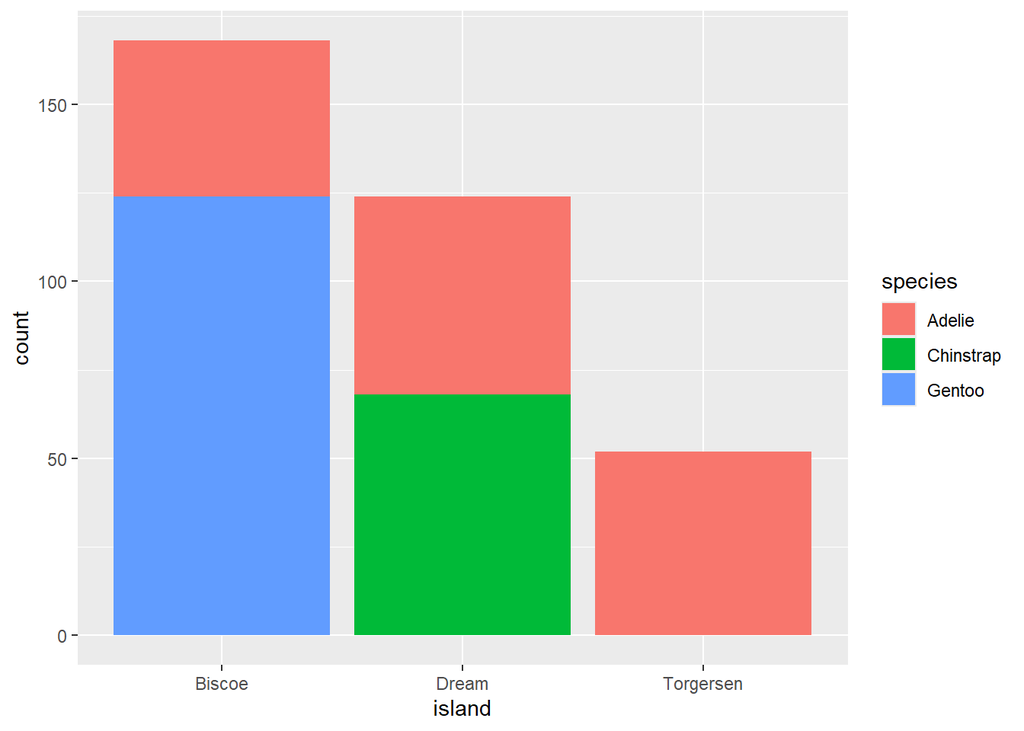

```r
ggplot(penguins, aes(x = island, fill = species)) +
  geom_bar()
```

```r
ggplot(penguins, aes(x = island, fill = species)) +
  geom_bar(position = "fill")
```

In creating these bar charts, we map the variable that will be separated into bars to the `x` aesthetic, and the variable that will change the colors inside the bars to the `fill` aesthetic. Unfortunately, ggplot2 labels the y-axis `"count"` by default, but this is something we can override by adding a `labs()` layer where we specify the y-axis label as `"proportion"`.

```r
ggplot(penguins, aes(x = island, fill = species)) +
  geom_bar(position = "fill") +
  labs(y = "proportion")
```

### Two numerical variables

So far you’ve learned about scatterplots (created with `geom_point()`) and smooth curves (created with `geom_smooth()`) for visualizing the relationship between two numerical variables. A scatterplot is probably the most commonly used plot for visualizing the relationship between two numerical variables.

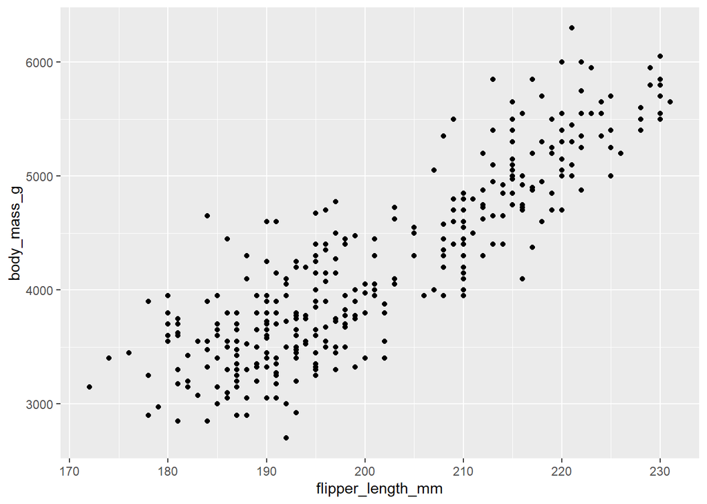

```r
ggplot(penguins, aes(x = flipper_length_mm, y = body_mass_g)) +
  geom_point()
```

### Three or more variables

As we saw in **Adding aesthetics and layers**, we can incorporate more variables into a plot by mapping them to additional aesthetics. For example, in the following scatterplot the colors of points represent species and the shapes of points represent islands.

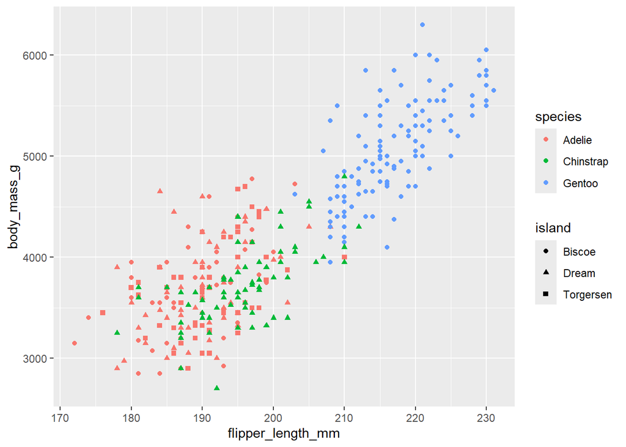

```r
ggplot(penguins, aes(x = flipper_length_mm, y = body_mass_g)) +
  geom_point(aes(color = species, shape = island))
```

However adding too many aesthetic mappings to a plot makes it cluttered and difficult to make sense of. Another way, which is particularly useful for categorical variables, is to split your plot into **facets**, subplots that each display one subset of the data.

To facet your plot by a single variable, use `facet_wrap()`. The first argument of `facet_wrap()` is a formula[^4], which you create with `~` followed by a variable name. The variable you give R inside `facet_wrap()` should be categorical.

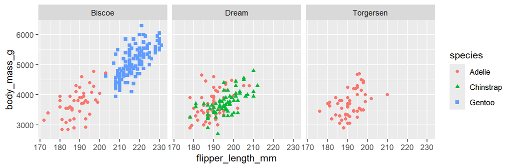

```r
ggplot(penguins, aes(x = flipper_length_mm, y = body_mass_g)) +
  geom_point(aes(color = species, shape = species)) +
  facet_wrap(~island)
```

### Data Visualization: Exercises 3

1. The `mpg` data frame that is bundled with the ggplot2 package contains 234 observations collected by the US Environmental Protection Agency on 38 car models. Which variables in `mpg` are categorical? Which variables are numerical? (Hint: Type `?mpg` to read the documentation for the dataset.) How can you see this information when you run `mpg`?
2. Make a scatterplot of `hwy` vs. `displ` using the `mpg` data frame. Next, map a third, numerical variable to `color`, then `size`, then both `color` and `size`, then `shape`. How do these aesthetics behave differently for categorical vs. numerical variables?
3. Why does the following yield two separate legends? How would you fix it to combine the two legends?

   ```r
   ggplot(
     data = penguins,
     mapping = aes(
       x = bill_length_mm, y = bill_depth_mm,
       color = species, shape = species
     )
   ) +
     geom_point() +
     labs(color = "Species")
   ```

4. Create the two following stacked bar plots. Which question can you answer with the first one? Which question can you answer with the second one?

   ```r
   ggplot(penguins, aes(x = island, fill = species)) +
     geom_bar(position = "fill")
   ```

   ```r
   ggplot(penguins, aes(x = species, fill = island)) +
     geom_bar(position = "fill")
   ```

## Saving your plots

Once you’ve made a plot, you might want to get it out of R by saving it as an image that you can use elsewhere. That’s the job of `ggsave()`, which will save the plot most recently created to disk:

```r
ggplot(penguins, aes(x = flipper_length_mm, y = body_mass_g)) +
  geom_point()
```

```r
ggsave(filename = "penguin-plot.png")
```

This will save your plot to your working directory.

If you don’t specify the `width` and `height` they will be taken from the dimensions of the current plotting device. For reproducible code, you’ll want to specify them. You can learn more about `ggsave()` in the documentation.

### Data Visualization: Exercises 4

1. Run the following lines of code. Which of the two plots is saved as `mpg-plot.png`? Why?

   ```r
   ggplot(mpg, aes(x = class)) +
     geom_bar()
   ggplot(mpg, aes(x = cty, y = hwy)) +
     geom_point()
   ggsave("mpg-plot.png")
   ```

2. What do you need to change in the code above to save the plot as a PDF instead of a PNG? How could you find out what types of image files would work in `ggsave()`?

## Common problems

As you start to run R code, you’re likely to run into problems. Don’t worry — it happens to everyone. We have all been writing R code for years, but every day we still write code that doesn’t work on the first try!

Start by carefully comparing the code that you’re running to the code in the book. R is extremely picky, and a misplaced character can make all the difference. Make sure that every `(` is matched with a `)` and every `"` is paired with another `"`. Sometimes you’ll run the code and nothing happens. Check the left-hand of your console: if it’s a `+`, it means that R doesn’t think you’ve typed a complete expression and it’s waiting for you to finish it. In this case, it’s usually easy to start from scratch again by pressing ESCAPE to abort processing the current command.

One common problem when creating ggplot2 graphics is to put the `+` in the wrong place: it has to come at the end of the line, not the start. In other words, make sure you haven’t accidentally written code like this:

```r
ggplot(data = mpg)
+ geom_point(mapping = aes(x = displ, y = hwy))
```

If you’re still stuck, try the help. You can get help about any R function by running `?function_name` in the console, or highlighting the function name and pressing F1 in RStudio. Don’t worry if the help doesn’t seem that helpful - instead skip down to the examples and look for code that matches what you’re trying to do.

If that doesn’t help, carefully read the error message. Sometimes the answer will be buried there! But when you’re new to R, even if the answer is in the error message, you might not yet know how to understand it. Another great tool is Google: try googling the error message, as it’s likely someone else has had the same problem, and has gotten help online.

## Summary

In this chapter, you’ve learned the basics of data visualization with ggplot2. We started with the basic idea that underpins ggplot2: a visualization is a mapping from variables in your data to aesthetic properties like position, color, size and shape. You then learned about increasing the complexity and improving the presentation of your plots layer-by-layer. You also learned about commonly used plots for visualizing the distribution of a single variable as well as for visualizing relationships between two or more variables, by leveraging additional aesthetic mappings and/or splitting your plot into small multiples using faceting.

# Part 3: Data Tables

*BEE instructions: If you are familiar with working with R and know how to manipulate your data, feel free to skip this section and go straight to working on your project. If not, follow along for the next section.*

You have already seen examples of collecting vectors, naming them, and putting them in a “table” in R. Once you view it, by clicking on it in the environment section, it looks a lot like an Excel sheet. Here you will see the huge improvements to working with R. You can edit existing variables, create new ones, and in general manipulate your data table much easier in R than Excel. The degree to which this is easier scales with the difficulty of the problem you are facing.

## Reading and Writing Data

You will almost never manually create a data table like how I did earlier, in order to create examples. The only time I ever do is to make small data with really weird cases to check my programming logic is correct (and to make these notes). You will typically be reading and writing to data stored on your computer, or, in more advanced cases, directly through the internet. Here I will only cover reading and writing to a csv. It is basically an Excel file. When you load a csv on your computer it takes you to Excel. csv stands for “comma separated values”. It just stores data as it is displayed in an Excel sheet, just the data in each cell is separated by a comma. In economics a lot of publicly available data is stored this way. It is probably the easiest and most universal way to store basic data, hence why we will be using it here. As your computing needs grow you will need to graduate from using csv files. But not today.

Say you have the csv in your computer with the file name `"C:/Users/person/Desktop/folder_1/folder_2/data_folder/file.csv"` The .csv at the end tells us it is a csv. We will load-in (“read”) files of this type with `fread`, like

```r
#### Do NOT type this -- Example only ####
dir = "C:/Users/person/Desktop/folder_1/folder_2/data_folder/"
dt = fread(paste0(dir, "file.csv"))
```

We now have the data table `dt` in our environment. Say we did a bunch of manipulation to `dt` and end-up with the table `dt_manip`. We want to save it (“write” it) to the computer in the same directory, `dir`. We will use `fwrite`:

```r
#### Do NOT type this -- Example only ####
output_file = "file_manipulated.csv"
fwrite(dt_manip, paste0(dir, output_file))
```

(If you are outputting into a different directory, say `dir_manip`, then use that above instead of `dir`. You will usually want to do this: Separate inputs and outputs. See the organization section above.)

```r
dir = "C:/Users/person/Desktop/BEE/data/"
dt = fread(paste0(dir, "example_data.csv"))
```

## Viewing Data

In this section `dt` will denote an arbitrary data table. Previously we have used names like `example_data` and `table`.

If you want to put the entire table in your programs tabs to view like an Excel sheet, then click the table in the environment. If your table is more than a few hundred rows or more than about twenty columns this will quickly become cumbersome, as you might, say, want to quickly look at row $100,000$ or the first fifteen rows where the variable `age` is $23$. This might not be in your table until row $100,001$, so you will not want to scroll down that far. Hence, we need to learn how to quickly view the part of the data we want. We will be using the scary console.

To print all rows, use `dt[]`. If there are a lot of rows this will print the first and last five of the table. To get specific row numbers (or just a number), put the number(s) of the rows you want inside the brackets. This works like accessing the information in a vector.

```r
dt[1]
dt[c(1,2,3)]
dt[1:3]

dt[17]
```

Line 1 returns the first row, since the row indexing starts at one. Lines 2 and 3 do the same thing by returning the first three rows, since `c(1,2,3)` and `1:3` are the same vector (of indices here). Line 5 will return a table with missing (`NA`) values in the columns since there is no row 17, since there are only 16 rows. Here are the actual four outputs:

```
##    category  group average  year gender
##      <char> <char>   <num> <num> <char>
## 1:   Gender   Male      10  2010   Male
```

```
##    category  group average  year gender
##      <char> <char>   <num> <num> <char>
## 1:   Gender   Male      10  2010   Male
## 2:   Gender Female      13  2010 Female
## 3:   Gender   Male      11  2011   Male
```

```
##    category  group average  year gender
##      <char> <char>   <num> <num> <char>
## 1:   Gender   Male      10  2010   Male
## 2:   Gender Female      13  2010 Female
## 3:   Gender   Male      11  2011   Male
```

```
##    category  group average  year gender
##      <char> <char>   <num> <num> <char>
## 1:     <NA>   <NA>      NA    NA   <NA>
```

Say we want the rows where the variable `group` is $23$, similar to the prior example. Then

```r
dt[group == "23"]
```

returns the rows where this is true. It is the same as passing a logical vector of true and false values into our table, where there are `FALSE`s where `group` is not `"23"` and are `TRUE`s where `group` is `"23"`. I hope you see the point of the overly long sections on vectors and logical conditions now.

Something similar holds with the columns. The columns are ordered like the rows are, with the leftmost column being $1$. Hence, you can print/return all rows of the second column (or the first and last 5 rows of it, if the data is large) similarly, like:

```r
dt[, 2]
```

```
##        group
##       <char>
##  1:     Male
##  2:   Female
##  3:     Male
##  4:   Female
##  5:     Male
##  6:   Female
##  7:    White
##  8:    Black
##  9: Hispanic
## 10:    White
## 11:    Black
## 12: Hispanic
## 13:    White
## 14:    Black
## 15: Hispanic
## 16:       23
```

Note the comma: Rows are before the comma and columns are after, just like how we organize a matrix (do not worry if you do not know what that is). You can combine these to get even more specific. The following prints/returns the third row of the second column:

```r
dt[3, 2]
```

```
##     group
##    <char>
## 1:   Male
```

You will instead access the columns/variables by their names. Our second column is `group` (this is the main reason to print the first row with `dt[1]`, to remind yourself what the column names are), and so instead of putting a 2 there we can put its name, like so:

```r
dt[group == "23", group]
```

```
## [1] "23"
```

What if you want multiple columns to be returned? The columns are vectors, so you can do this to return the columns `group` and `average`:

```r
dt[group == "23", c("group", "average")]
```

```
##     group average
##    <char>   <num>
## 1:     23      10
```

This is annoying and slow to type with the quotes around them. Thankfully, we can do this:

```r
dt[group == "23", .(group, average)]
```

```
##     group average
##    <char>   <num>
## 1:     23      10
```

Note the `.` in front. There is a technical name for doing that. Let the nerds worry about that. You still needs the parenthesis around the list of comma-separated variables names.

## Manipulating Data

Let’s say you want a column full of 1s. I’m not sure why, but let’s say you do. We add columns to the table with the `:=` operator (you will see this eventually in math classes; economists like to use ≡; yuck). Assignment works like assigning information to a name at the beginning of this tutorial, but since this is a column it needs to go after the comma:

```r
dt[, column_of_ones := 1]

dt[, column_of_ones_long := c(1,1,1,1,1,1,1,1,1,1,1,1,1,1,1,1)]

dt[group=="23", one := 1]

dt[category=="Gender",
   F_M_ratio := average[gender=="Female"]/average[gender=="Male"],
   by = year]
```

Line 1 is how you should do it. Line 3 shows what R is really doing, since creating a new variable is the same thing as creating a new vector and putting it in the table. Note that the vector I assigned was length 16, the length of the table. R will give us (“throw”) an error if we attempt to assign a variable of another length.

Line 7 combines what line 5 did with an example of a more complicated manipulation. On the set where Male/Female makes sense (where `category=="Gender"`), we assign the `F_M_ratio` for each year. We did nearly the same thing in a prior example. To do it for each year we needed the `by = year` at the end, since otherwise the `average[gender==]` call would result in a vector, the values across all of the years. I will cover that in the next subsection.

We can perform all other standard operations between variables (again, to be thought of as vectors) in our table. Here I will make a different table to demonstrate the more basic operations:

```r
DT = data.table(
  x=c(1,2,3,7,8),
  y=c(2,2,2,3,4)
)

DT[, z := x+y]
DT[, w := x-y]
# The ':'( just means everything inside the parentheses gets created, and we no longer need the colon, just the = sign. It can save space in your file.
DT[, ':='(u = x*y, v = x/y)]
DT[, log_y := log(y)]

DT
```

```
##        x     y     z     w     u        v     log_y
##    <num> <num> <num> <num> <num>    <num>     <num>
## 1:     1     2     3    -1     2 0.500000 0.6931472
## 2:     2     2     4     0     4 1.000000 0.6931472
## 3:     3     2     5     1     6 1.500000 0.6931472
## 4:     7     3    10     4    21 2.333333 1.0986123
## 5:     8     4    12     4    32 2.000000 1.3862944
```

Once we create the table `DT` we create other variables with common operations. `z`, `w`, `u`, and `v` are the sum of, difference o, product of, and quotient of `x` and `y` as vectors, respectively. I say “as vectors” because these are performed entry-wise: Each row has `z` as the sum of that row’s value of `x` and `y`, and the same goes for the other three variables. `log_y` looks a bit different, but it is conceptually the same. It is the natural logarithm function applied to each row’s value of `y`.

The last two variables created are a bit special, since they are not computed entry-wise. The mean of `x` and variance of `z` are computed over the whole vector/variable, not just that row (as `x`+`y` is, for example). It is the same as computing the mean and variance over each variable as a vector, saving those values, and assigning every row that single value as we did with assigning ones before. You should check that this does the same:

```r
DT[, mean_x := mean(x)]
DT[, var_z := var(z)]

mean_x_value = mean(DT[, x])
var_z_value = var(DT[, z])

DT[, ':='(mean_x=mean_x_value, var_z=var_z_value)]
```

I do not print `DT` so you can check it.

## Grouping Data

Earlier we had a mysterious `by = year` at the end of our `dt` call:

```r
dt[category=="Gender",
   F_M_ratio := average[gender=="Female"]/average[gender=="Male"],
   by = year]
```

This grouped our data together for each year.

We do this all the time in data science: Group rows together by the `year`, or the `month`, or the `gender`, or the `location`, etc. and create a new variable that is defined over each possible value you can group by. The possible values for `year` were $2010, 2011$, and $2012$, so it created `F_M_ratio` over each of these years. We do this particularly often when we want summary stats for each group: Get the average of `x` for each month; the average of `y` for each county; the variance of `z` for each possible *combination* of year, month, and county in our dataset. This last example notes that we can group by multiple variables at once.

```r
DT = data.table(
  year=c(2024,2024,2024,2024, 2025,2025,2025,2025),
  month=c(1,1,12,12,  1,1,12,12),
  county=c("Hennepin","Ramsey","Hennepin","Ramsey",
           "Hennepin","Ramsey","Hennepin","Scott"),

  x=1:8
)

DT[, mean_year_x := mean(x), by = year]
```

We took the mean of `x` just grouping by the `year`. That is, we did not consider that the `month` or `county` could vary within the `year`. But, we can with

```r
DT[, mean_year_month_x := mean(x), by = .(year, month)]
DT[, mean_year_month_county_x := mean(x), by = .(year, month, county)]
```

When grouping by multiple variables we list them like we did in Section $3.1$, with `.()` (likewise, we can make it a vector of strings of the variable names, but this was here is quicker). Line $1$ groups by both `year` and `month`. Hence, we will take the average across every county in every possible `year` $\times$ `month` combination. Line $2$ groups by `year`, `month`, and `county`. Note that in this example there is only ever one value of `year` $\times$ `month` $\times$ `county`: There is never more than one row that has the same `year`, `month`, and `county`. Hence, the average will just be the value of `x` itself, as you should verify.

## Collapsing (Summarizing) Data

Everything you have seen thus far involves adding a new column to the table, with the `:=` operator (for potential comp. sci. people this really means the columns are added by reference). Doing so does not change anything already in the table. But sometimes we might not want that. For instance, in our last example, if we just wanted the annual mean of `x`, then using `:=` adds a column that could be redundant if we do not need this extra column for any other purpose. You will encounter this a lot, where you want some summary statistic(s), but it does not need to go in your main data. (In fact, cluttering your main data table with summary statistics that you do not need for future manipulation but only to view is actively discouraged.)

To do so in the simple version we just drop mention of the `:=`.

```r
DT[, mean(x), by = year]
```

```
##     year    V1
##    <num> <num>
## 1:  2024   2.5
## 2:  2025   6.5
```

```r
DT[, .(mean_year_x = mean(x)), by = year]
```

```
##     year mean_year_x
##    <num>       <num>
## 1:  2024         2.5
## 2:  2025         6.5
```

```r
DT[, .(mean_x_year_county = mean(x)), by = .(year, county)]
```

```
##     year   county mean_x_year_county
##    <num>   <char>              <num>
## 1:  2024 Hennepin                  2
## 2:  2024   Ramsey                  3
## 3:  2025 Hennepin                  6
## 4:  2025   Ramsey                  6
## 5:  2025    Scott                  8
```

Line $1$ accomplishes what line $10$ did two examples ago in terms of the values it produces. You should check that they are the same. But, you will notice that there are now only two rows, the number of `year`s in the table. We did not use `:=`, so there was not a new column added, so any information (rows and columns) that are not the data we are manipulating to create summary statistics (`x`) and the variable we are grouping by and its levels (`year`) get dropped. In line $4$ here I group by `year` and `county`, so summary table will now have three columns: `year` and `county` that has every possible combination of them in the table, and `mean_x_year_county` that is the mean of `x` over the rows that match each combination.

In line $3$ I also introduced how you can name the variable you are summarizing. If you do not supply a name it will default to things like `V1`. Note that it is still inside `.()`. This also applies to when we want to summarize multiple variables or in multiple ways over the same grouping:

```r
# Add a variable y so we have multiple numeric variables
DT[, y := 5:12]

DT[, .(mean_year_x = mean(x), mean_year_y = mean(y)), by = year]
```

```
##     year mean_year_x mean_year_y
##    <num>       <num>       <num>
## 1:  2024         2.5         6.5
## 2:  2025         6.5        10.5
```

```r
DT[, .(mean_year_x = mean(x), var_year_x = var(x)), by = year]
```

```
##     year mean_year_x var_year_x
##    <num>       <num>      <num>
## 1:  2024         2.5   1.666667
## 2:  2025         6.5   1.666667
```

Optional: If a variable is constant within each combination of values of what you are grouping by, then you can include it in the summary stats by including it in the variables you are creating. For instance, if `code` is the same in every year, then you can write

```r
DT[, .(mean_year_x = mean(x), code), by = year]
```

and still have `code` appear as a variable. Now, if `code` varies within any level of `year` (e.g. in $2024$ it has two possible values, $1$ and $2$), then our data will no longer collapse down into unique years of the table, as we have not supplied a way to summarize it.

# Examples and Practice

Here we will load-in data that you will use as part of one of the BEE lectures. It has income percentiles for different demographic groups (age groups, race, foreign- or U.S.-born, and gender, as well as product variables thereof) in the United States for different income variables, in different states, and for some different underlying population samples.

We load up the data and look at the first row to see the variables and the type of data:

```r
file_name = paste0(getwd(),"/data/percentiles_combined.csv")
pctls = fread(file_name)

pctls[1]
```

```
##     year  level           samp inc_var geo_var geo_var_val geo_abb group_var group_var_val  pctl
##    <int> <char>         <char>  <char>  <char>       <int>  <char>    <char>        <char> <num>
## 1:  1998  mafid all_1040_mafid      WS    usst           0      US     xaged        16to24    10
##    value       pce value_real
##    <num>     <num>      <num>
## 1:  6969 0.6856143   10164.61
```

(In your output, if your console section is sufficiently wide, then this should output on one line. Here it looks more messy than it normally is.)

I subset the entire data `pctls` to smaller data, `data`, so then we only have the rows we want. I then split the data into two again, the male-male comparison and the female-male comparison. Here is the code:

```r
data = pctls[samp == "prime_age_working_w2" & inc_var == "TC" & group_var=="xredXsex" &
               group_var_val%in%c("NH_White_Male","NH_Black_Male","NH_Black_Female") &
               geo_var == "usst" & 25 <= pctl & pctl <= 99.9
]
data_male = data[group_var_val%in%c("NH_White_Male","NH_Black_Male"),
                 .(ratio = value[group_var_val=="NH_Black_Male"]/value[group_var_val=="NH_White_Male"]),
                 by = .(year, pctl)]
data_female = data[group_var_val%in%c("NH_White_Male","NH_Black_Female"),
                   .(ratio = value[group_var_val=="NH_Black_Female"]/value[group_var_val=="NH_White_Male"]),
                   by = .(year, pctl)]
```

Graphing for most of our basic purposes in two weeks will be easy. It is also easy to try to spend too much time making plots look trivially nicer. Try not to do that for what are rough drafts. Here is the code for our first graph:

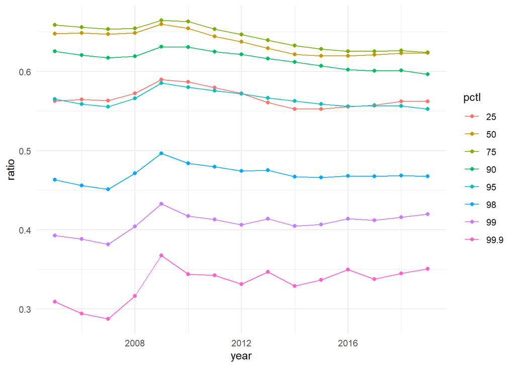

```r
library(ggplot2)

data_male[, pctl := as.factor(pctl)]
ggplot(data_male, aes(x=year, y=ratio, color=pctl, group=pctl)) +
  geom_point() + geom_line() +
  theme_minimal()
```

And here is the second.

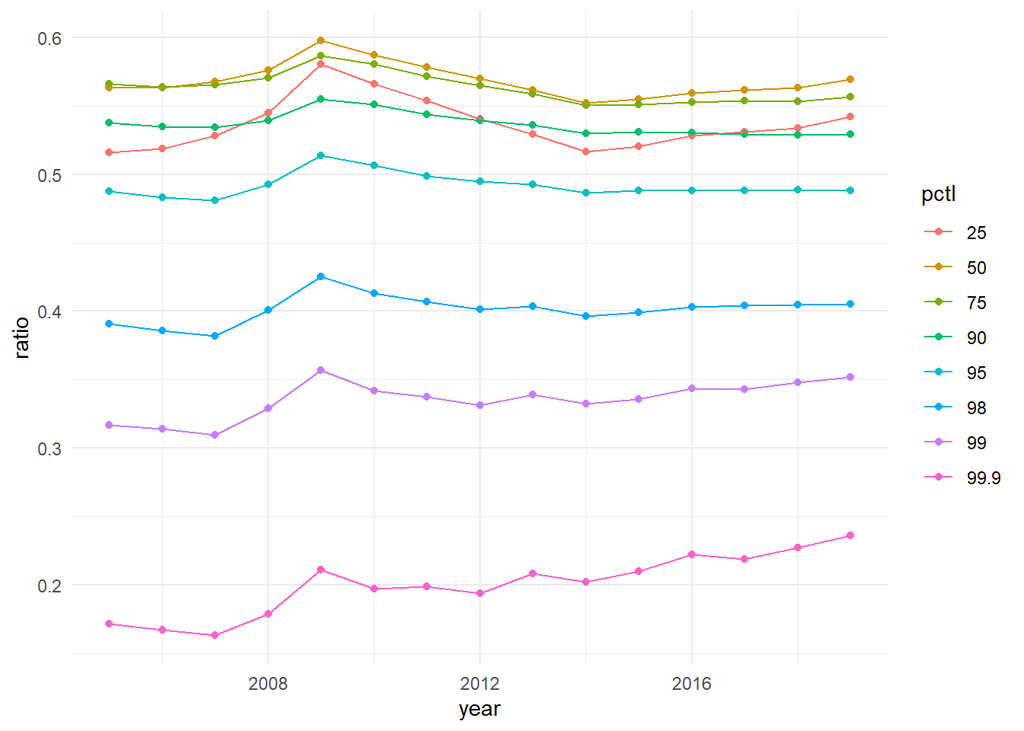

```r
data_female[, pctl := as.factor(pctl)]
ggplot(data_female, aes(x=year, y=ratio, color=pctl)) +
  geom_point() + geom_line() +
  theme_minimal()
```

We needed to put the variable `pctl` as a `factor` for reasons you should not worry about now. But, any time you have groups of something (so to create this you grouped by it, and in the plotting you made the colors group by it), you should do this before plotting. The general syntax is

```r
ggplot(dt, aex(x = x_variable, y = y_variable, colour = group_variable, group = group_variable)) +
  geom_point() + geom_line() +
  theme_minimal()
```

Our `x` variable was `year`, our `y` variable was `ratio`, and we wanted our data to connect the dots to form a line based upon `pctl`, so we told R to color by it and group them together.

[^1]: You can eliminate that message and force conflict resolution to happen on demand by using the conflicted package, which becomes more important as you load more packages. You can learn more about conflicted at https://conflicted.r-lib.org.
[^2]: Horst AM, Hill AP, Gorman KB (2020). palmerpenguins: Palmer Archipelago (Antarctica) penguin data. R package version 0.1.0. https://allisonhorst.github.io/palmerpenguins/. doi: 10.5281/zenodo.3960218.
[^3]: Not to mention that you’re tempting fate by using “final” in the name 😆 The comic Piled Higher and Deeper has a [fun strip on this](https://phdcomics.com/comics/archive.php?comicid=1531).
[^4]: Here “formula” is the name of the thing created by `~`, not a synonym for “equation”.